# Introduction to R

09/03/2018

## Welcome - Ben

- Who Am I? 2018 CSB graduate, former tutor in statistics and econometrics at Unimelb
- R user for 2 years, self-taught for empirical research and research assistant work. Now a self-processed stats/coding nerd
- Follow me on twitter: @BenwWee

## Welcome - Steph

- Who am I? Also a 2018 grad, doing my first rotation in Telstra Software Engineering Service Assurance & Billing team. Last year I was a 2017 summer vac in Finance Strategy team.
- I recently graduated UNSW, studying Computer Science & Commerce. I've been using R for about 4 years, in the context of marketing analytics and machine learning in university level courses.
- I don't use twitter ^_^

## What is R and Rstudio?

- R is a free and open source statistical programming language and software environment.
- Rstudio is an Integrated Development Environment (IDE). It provides an intuitive workspace for working with R.
- R facilitates a complete data analysis workflow from loading/cleaning data to producing publishable and reproducible documents/slides.
- Used by analysts, statisticians and data scientists for data cleaning, manipulation, modelling and visualisation

## What are we learning today?

- Navigating through Rstudio
- Running basic commands and understanding workflow for data driven analysis
- The key goal for today is to get everyone **comfortable** with the Rstudio interface and motivated to learn more about coding!
- Only a *taste* of what R can do. Packages used are meant to be user-friendly for "non-programmers" and to improve overall efficiency of data wraggling

## Let's start!

- What is the most important thing to do when learning to code for the first time?
- Changing the colour scheme so you look cool!

## Conclusion

- Thank you for attending this session! I hope you all had a good time and feel inspired to learn more about R
- Please join our yammer group: R users
- Potential classes:
  - Loading in different types of spreadsheets (loading in data directly from internet)
  - Understanding the principles of 'clean' or 'tidy' data
  - More fun with ggplot2!
  - Use of base R functions for more niche cases (indexing data, conditional statements, booleens)

## Learning R independently

- R makes doing easy things in Excel hard but hard things in Excel very easy
- Excel allows you to have any "data type" (think numbers, characters, etc) and output in any cell. R forces each column to have the same data type. With a constraint, you are forced to pay more attention to what your data is and how you perform analysis
- You will be forced to think more critically about your data. We will sacrifice convenience for precision and efficiency

## Learning R independently

- Learning to code is not something you can do by attending many classes (how much did you learn in lecutres?)
- If you intend to learn R for data analysis, you need to have the bigger picture in mind. You will **need** to struggle through lots of errors and frustration to get basic stuff done
- But I believe this investment can add *heaps* of value in the long run and make your analysis more robust (and your charts/graphs prettier)
- My tip is to have a data problem in mind that you can use R to solve. That way you figure out what you don't know and you can structure your learning and start asking the right questions.

## Very common errors and problems you will deal with

- **Common Errors**
  - Most of the time, these are syntax errors (forgetting a bracket or comma are the biggest culprits)
  - Forgetting to assign variables (check your enviornment)
- **Diagnostics**
  - If you have '+' in your console everytime you try to run code, you forgot to close a bracket. R thinks you are adding inputs into a function.

## Where to go for help

- Google it!
- Often google will lead you to stack exchange where a lot of people ask the same questions
- Much of the learning process is understanding *how* to google questions. If your question doesn't yield the answer you want, try asking it in a different way, you will eventually come to the solution
- Ask us! :)

## Resources and cheat sheets

- Dplyr cheatsheet: https://www.rstudio.com/wp-content/uploads/2015/02/data-wrangling-cheatsheet.pdf
- ggplot2 cheatsheet: https://www.rstudio.com/wp-content/uploads/2015/03/ggplot2-cheatsheet.pdf

## Why can R do for you?

- R can automate and apply functions quickly over many datasets more efficiently than Excel
- Massive library full of packages (add-ons) which contribute to a large huge visualiastion and modelling libraries
- It is *much* easier to reproduce results and debug without having to worry about multiple tabs, linked formulas and stuff breaking
- Scripting allows you to identify where you made mistakes in your process quickly and then re-run your analysis so that everything is updated immediately
- Excel formulas and functions are stored in the same place. This makes it prone to mistakes. Also slow with large datasets
- It is free and you look cool

## Learning curves

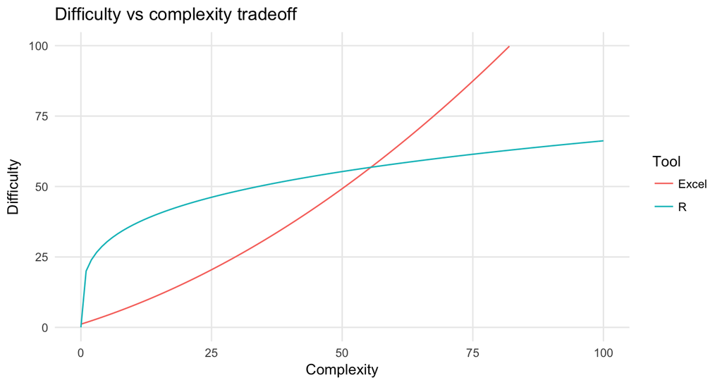